# Risk Factor Analysis

## Outcome Variable

**Outcome Variable:** ever_sstunted

## Predictor Variables

**Intervention Variable:** single

**Adjustment Set:**

- arm
- W_mage
- meducyrs
- feducyrs
- W_mhtcm
- W_mwtkg
- W_mbmi
- delta_W_mage
- delta_meducyrs
- delta_feducyrs
- delta_W_mhtcm
- delta_W_mwtkg
- delta_W_mbmi

## Stratifying Variables

The analysis was stratified on these variable(s):

- agecat
- studyid
- country

## Data Summary

| agecat | studyid | country | single | ever_sstunted | n_cell | n |
| --- | --- | --- | --- | --- | --- | --- |
| 0-24 months | COHORTS | GUATEMALA | 0 | 0 | 582 | 1207 |
| 0-24 months | COHORTS | GUATEMALA | 0 | 1 | 527 | 1207 |
| 0-24 months | COHORTS | GUATEMALA | 1 | 0 | 43 | 1207 |
| 0-24 months | COHORTS | GUATEMALA | 1 | 1 | 55 | 1207 |
| 0-24 months | COHORTS | INDIA | 0 | 0 | 4639 | 5384 |
| 0-24 months | COHORTS | INDIA | 0 | 1 | 736 | 5384 |
| 0-24 months | COHORTS | INDIA | 1 | 0 | 7 | 5384 |
| 0-24 months | COHORTS | INDIA | 1 | 1 | 2 | 5384 |
| 0-24 months | COHORTS | PHILIPPINES | 0 | 0 | 1889 | 3018 |
| 0-24 months | COHORTS | PHILIPPINES | 0 | 1 | 1054 | 3018 |
| 0-24 months | COHORTS | PHILIPPINES | 1 | 0 | 50 | 3018 |
| 0-24 months | COHORTS | PHILIPPINES | 1 | 1 | 25 | 3018 |
| 0-24 months | Guatemala BSC | GUATEMALA | 0 | 0 | 207 | 282 |
| 0-24 months | Guatemala BSC | GUATEMALA | 0 | 1 | 45 | 282 |
| 0-24 months | Guatemala BSC | GUATEMALA | 1 | 0 | 22 | 282 |
| 0-24 months | Guatemala BSC | GUATEMALA | 1 | 1 | 8 | 282 |
| 0-24 months | JiVitA-4 | BANGLADESH | 0 | 0 | 4312 | 5423 |
| 0-24 months | JiVitA-4 | BANGLADESH | 0 | 1 | 1103 | 5423 |
| 0-24 months | JiVitA-4 | BANGLADESH | 1 | 0 | 8 | 5423 |
| 0-24 months | JiVitA-4 | BANGLADESH | 1 | 1 | 0 | 5423 |
| 0-24 months | MAL-ED | BANGLADESH | 0 | 0 | 207 | 265 |
| 0-24 months | MAL-ED | BANGLADESH | 0 | 1 | 58 | 265 |
| 0-24 months | MAL-ED | BANGLADESH | 1 | 0 | 0 | 265 |
| 0-24 months | MAL-ED | BANGLADESH | 1 | 1 | 0 | 265 |
| 0-24 months | MAL-ED | BRAZIL | 0 | 0 | 183 | 233 |
| 0-24 months | MAL-ED | BRAZIL | 0 | 1 | 14 | 233 |
| 0-24 months | MAL-ED | BRAZIL | 1 | 0 | 28 | 233 |
| 0-24 months | MAL-ED | BRAZIL | 1 | 1 | 8 | 233 |
| 0-24 months | MAL-ED | INDIA | 0 | 0 | 192 | 249 |
| 0-24 months | MAL-ED | INDIA | 0 | 1 | 57 | 249 |
| 0-24 months | MAL-ED | INDIA | 1 | 0 | 0 | 249 |
| 0-24 months | MAL-ED | INDIA | 1 | 1 | 0 | 249 |
| 0-24 months | MAL-ED | NEPAL | 0 | 0 | 219 | 240 |
| 0-24 months | MAL-ED | NEPAL | 0 | 1 | 21 | 240 |
| 0-24 months | MAL-ED | NEPAL | 1 | 0 | 0 | 240 |
| 0-24 months | MAL-ED | NEPAL | 1 | 1 | 0 | 240 |
| 0-24 months | MAL-ED | PERU | 0 | 0 | 214 | 303 |
| 0-24 months | MAL-ED | PERU | 0 | 1 | 54 | 303 |
| 0-24 months | MAL-ED | PERU | 1 | 0 | 25 | 303 |
| 0-24 months | MAL-ED | PERU | 1 | 1 | 10 | 303 |
| 0-24 months | MAL-ED | SOUTH AFRICA | 0 | 0 | 138 | 314 |
| 0-24 months | MAL-ED | SOUTH AFRICA | 0 | 1 | 38 | 314 |
| 0-24 months | MAL-ED | SOUTH AFRICA | 1 | 0 | 103 | 314 |
| 0-24 months | MAL-ED | SOUTH AFRICA | 1 | 1 | 35 | 314 |
| 0-24 months | MAL-ED | TANZANIA, UNITED REPUBLIC OF | 0 | 0 | 119 | 262 |
| 0-24 months | MAL-ED | TANZANIA, UNITED REPUBLIC OF | 0 | 1 | 133 | 262 |
| 0-24 months | MAL-ED | TANZANIA, UNITED REPUBLIC OF | 1 | 0 | 6 | 262 |
| 0-24 months | MAL-ED | TANZANIA, UNITED REPUBLIC OF | 1 | 1 | 4 | 262 |
| 0-24 months | PROBIT | BELARUS | 0 | 0 | 15765 | 16897 |
| 0-24 months | PROBIT | BELARUS | 0 | 1 | 439 | 16897 |
| 0-24 months | PROBIT | BELARUS | 1 | 0 | 665 | 16897 |
| 0-24 months | PROBIT | BELARUS | 1 | 1 | 28 | 16897 |
| 0-24 months | TanzaniaChild2 | TANZANIA, UNITED REPUBLIC OF | 0 | 0 | 1933 | 2375 |
| 0-24 months | TanzaniaChild2 | TANZANIA, UNITED REPUBLIC OF | 0 | 1 | 218 | 2375 |
| 0-24 months | TanzaniaChild2 | TANZANIA, UNITED REPUBLIC OF | 1 | 0 | 205 | 2375 |
| 0-24 months | TanzaniaChild2 | TANZANIA, UNITED REPUBLIC OF | 1 | 1 | 19 | 2375 |
| 0-24 months | ZVITAMBO | ZIMBABWE | 0 | 0 | 10952 | 14016 |
| 0-24 months | ZVITAMBO | ZIMBABWE | 0 | 1 | 2175 | 14016 |
| 0-24 months | ZVITAMBO | ZIMBABWE | 1 | 0 | 709 | 14016 |
| 0-24 months | ZVITAMBO | ZIMBABWE | 1 | 1 | 180 | 14016 |

The following strata were considered:

- agecat: 0-24 months, studyid: COHORTS, country: GUATEMALA
- agecat: 0-24 months, studyid: COHORTS, country: INDIA
- agecat: 0-24 months, studyid: COHORTS, country: PHILIPPINES
- agecat: 0-24 months, studyid: Guatemala BSC, country: GUATEMALA
- agecat: 0-24 months, studyid: JiVitA-4, country: BANGLADESH
- agecat: 0-24 months, studyid: MAL-ED, country: BANGLADESH
- agecat: 0-24 months, studyid: MAL-ED, country: BRAZIL
- agecat: 0-24 months, studyid: MAL-ED, country: INDIA
- agecat: 0-24 months, studyid: MAL-ED, country: NEPAL
- agecat: 0-24 months, studyid: MAL-ED, country: PERU
- agecat: 0-24 months, studyid: MAL-ED, country: SOUTH AFRICA
- agecat: 0-24 months, studyid: MAL-ED, country: TANZANIA, UNITED REPUBLIC OF
- agecat: 0-24 months, studyid: PROBIT, country: BELARUS
- agecat: 0-24 months, studyid: TanzaniaChild2, country: TANZANIA, UNITED REPUBLIC OF
- agecat: 0-24 months, studyid: ZVITAMBO, country: ZIMBABWE

### Dropped Strata

Some strata were dropped due to rare outcomes:

- agecat: 0-24 months, studyid: COHORTS, country: INDIA
- agecat: 0-24 months, studyid: JiVitA-4, country: BANGLADESH
- agecat: 0-24 months, studyid: MAL-ED, country: BANGLADESH
- agecat: 0-24 months, studyid: MAL-ED, country: INDIA
- agecat: 0-24 months, studyid: MAL-ED, country: NEPAL
- agecat: 0-24 months, studyid: MAL-ED, country: TANZANIA, UNITED REPUBLIC OF

## Methods Detail

We're interested in the causal parameters $E[Y_a]$ for all values of $a \in \mathcal{A}$. These parameters represent the mean outcome if, possibly contrary to fact, we intervened to set all units to have $A=a$. Under the randomization and positivity assumptions, these are identified by the statistical parameters $\psi_a=E_W[E_{Y|A,W}(Y|A=a,W)]$. In addition, we're interested in the mean of $Y$, $E[Y]$ under no intervention (the observed mean). We will estimate these parameters by using SuperLearner to fit the relevant likelihood factors -- $E_{Y|A,W}(Y|A=a,W)$ and $p(A=a|W)$, and then updating our likelihood fit using a joint TMLE.

For unadjusted analyses ($W=\{\}$), initial likelihoods were estimated using Lrnr_glm to estimate the simple $E(Y|A)$ and Lrnr_mean to estimate $p(A)$. For adjusted analyses, a small library containing Lrnr_glmnet, Lrnr_xgboost, and Lrnr_mean was used.

Having estimated these parameters, we will then use the delta method to estimate relative risks and attributable risks relative to a prespecified baseline level of $A$.

# Results Detail

## Results Plots

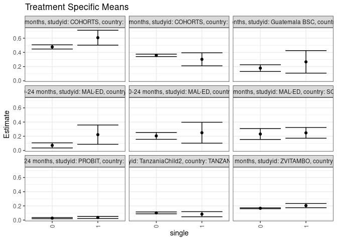

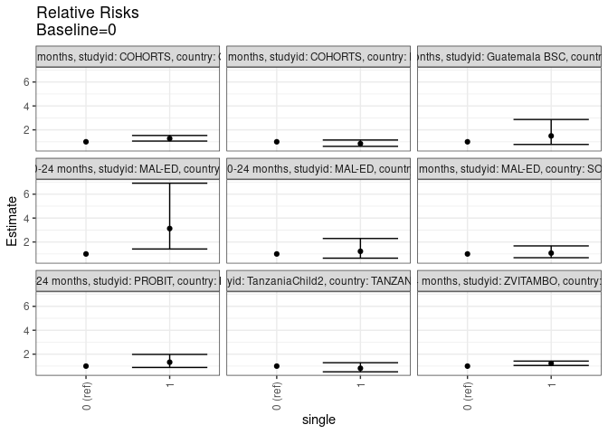

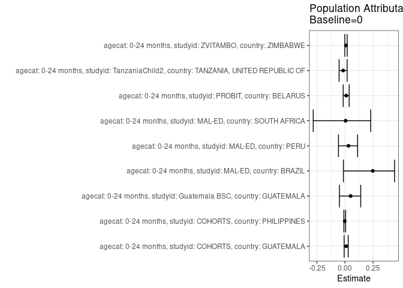

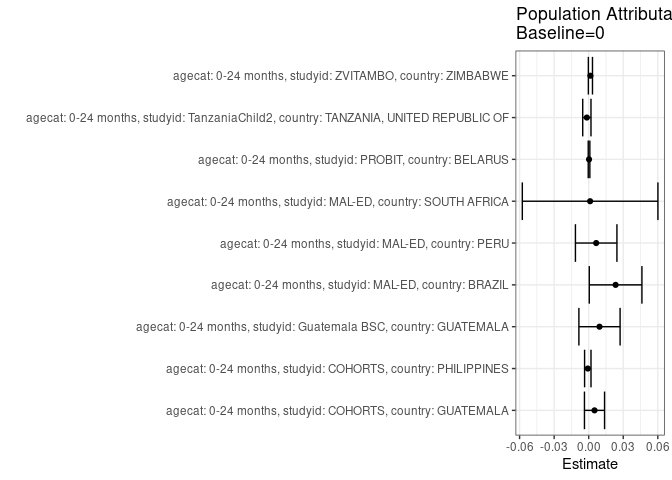

## Results Table

### Parameter: TSM

| agecat | studyid | country | intervention_level | baseline_level | estimate | ci_lower | ci_upper |
| --- | --- | --- | --- | --- | --- | --- | --- |
| 0-24 months | COHORTS | GUATEMALA | 0 | NA | 0.4771408 | 0.4476296 | 0.5066521 |
| 0-24 months | COHORTS | GUATEMALA | 1 | NA | 0.6071899 | 0.5019994 | 0.7123804 |
| 0-24 months | COHORTS | PHILIPPINES | 0 | NA | 0.3583057 | 0.3408978 | 0.3757136 |
| 0-24 months | COHORTS | PHILIPPINES | 1 | NA | 0.3025537 | 0.2107005 | 0.3944069 |
| 0-24 months | Guatemala BSC | GUATEMALA | 0 | NA | 0.1785714 | 0.1312007 | 0.2259422 |
| 0-24 months | Guatemala BSC | GUATEMALA | 1 | NA | 0.2666667 | 0.1081431 | 0.4251903 |
| 0-24 months | MAL-ED | BRAZIL | 0 | NA | 0.0710660 | 0.0351099 | 0.1070221 |
| 0-24 months | MAL-ED | BRAZIL | 1 | NA | 0.2222222 | 0.0861240 | 0.3583204 |
| 0-24 months | MAL-ED | PERU | 0 | NA | 0.2047269 | 0.1564684 | 0.2529854 |
| 0-24 months | MAL-ED | PERU | 1 | NA | 0.2495813 | 0.1022785 | 0.3968841 |
| 0-24 months | MAL-ED | SOUTH AFRICA | 0 | NA | 0.2312548 | 0.1543676 | 0.3081419 |
| 0-24 months | MAL-ED | SOUTH AFRICA | 1 | NA | 0.2477663 | 0.1722010 | 0.3233316 |
| 0-24 months | PROBIT | BELARUS | 0 | NA | 0.0273400 | 0.0196344 | 0.0350455 |
| 0-24 months | PROBIT | BELARUS | 1 | NA | 0.0362611 | 0.0215537 | 0.0509685 |
| 0-24 months | TanzaniaChild2 | TANZANIA, UNITED REPUBLIC OF | 0 | NA | 0.1013959 | 0.0886416 | 0.1141501 |
| 0-24 months | TanzaniaChild2 | TANZANIA, UNITED REPUBLIC OF | 1 | NA | 0.0830875 | 0.0471203 | 0.1190547 |
| 0-24 months | ZVITAMBO | ZIMBABWE | 0 | NA | 0.1665236 | 0.1601187 | 0.1729284 |
| 0-24 months | ZVITAMBO | ZIMBABWE | 1 | NA | 0.2039038 | 0.1745095 | 0.2332982 |

### Parameter: E(Y)

| agecat | studyid | country | intervention_level | baseline_level | estimate | ci_lower | ci_upper |
| --- | --- | --- | --- | --- | --- | --- | --- |
| 0-24 months | COHORTS | GUATEMALA | NA | NA | 0.4821872 | 0.4539860 | 0.5103885 |
| 0-24 months | COHORTS | PHILIPPINES | NA | NA | 0.3575215 | 0.3404198 | 0.3746233 |
| 0-24 months | Guatemala BSC | GUATEMALA | NA | NA | 0.1879433 | 0.1422658 | 0.2336207 |
| 0-24 months | MAL-ED | BRAZIL | NA | NA | 0.0944206 | 0.0567935 | 0.1320477 |
| 0-24 months | MAL-ED | PERU | NA | NA | 0.2112211 | 0.1651858 | 0.2572564 |
| 0-24 months | MAL-ED | SOUTH AFRICA | NA | NA | 0.2324841 | 0.1856873 | 0.2792809 |
| 0-24 months | PROBIT | BELARUS | NA | NA | 0.0276380 | 0.0201988 | 0.0350773 |
| 0-24 months | TanzaniaChild2 | TANZANIA, UNITED REPUBLIC OF | NA | NA | 0.0997895 | 0.0877330 | 0.1118460 |
| 0-24 months | ZVITAMBO | ZIMBABWE | NA | NA | 0.1680223 | 0.1618323 | 0.1742123 |

### Parameter: RR

| agecat | studyid | country | intervention_level | baseline_level | estimate | ci_lower | ci_upper |
| --- | --- | --- | --- | --- | --- | --- | --- |
| 0-24 months | COHORTS | GUATEMALA | 0 | 0 | 1.0000000 | 1.0000000 | 1.000000 |
| 0-24 months | COHORTS | GUATEMALA | 1 | 0 | 1.2725590 | 1.0595361 | 1.528411 |
| 0-24 months | COHORTS | PHILIPPINES | 0 | 0 | 1.0000000 | 1.0000000 | 1.000000 |
| 0-24 months | COHORTS | PHILIPPINES | 1 | 0 | 0.8444010 | 0.6208885 | 1.148375 |
| 0-24 months | Guatemala BSC | GUATEMALA | 0 | 0 | 1.0000000 | 1.0000000 | 1.000000 |
| 0-24 months | Guatemala BSC | GUATEMALA | 1 | 0 | 1.4933333 | 0.7788347 | 2.863309 |
| 0-24 months | MAL-ED | BRAZIL | 0 | 0 | 1.0000000 | 1.0000000 | 1.000000 |
| 0-24 months | MAL-ED | BRAZIL | 1 | 0 | 3.1269841 | 1.4129327 | 6.920379 |
| 0-24 months | MAL-ED | PERU | 0 | 0 | 1.0000000 | 1.0000000 | 1.000000 |
| 0-24 months | MAL-ED | PERU | 1 | 0 | 1.2190938 | 0.6478072 | 2.294185 |
| 0-24 months | MAL-ED | SOUTH AFRICA | 0 | 0 | 1.0000000 | 1.0000000 | 1.000000 |
| 0-24 months | MAL-ED | SOUTH AFRICA | 1 | 0 | 1.0714000 | 0.6854690 | 1.674617 |
| 0-24 months | PROBIT | BELARUS | 0 | 0 | 1.0000000 | 1.0000000 | 1.000000 |
| 0-24 months | PROBIT | BELARUS | 1 | 0 | 1.3263033 | 0.8888415 | 1.979071 |
| 0-24 months | TanzaniaChild2 | TANZANIA, UNITED REPUBLIC OF | 0 | 0 | 1.0000000 | 1.0000000 | 1.000000 |
| 0-24 months | TanzaniaChild2 | TANZANIA, UNITED REPUBLIC OF | 1 | 0 | 0.8194367 | 0.5224985 | 1.285126 |
| 0-24 months | ZVITAMBO | ZIMBABWE | 0 | 0 | 1.0000000 | 1.0000000 | 1.000000 |
| 0-24 months | ZVITAMBO | ZIMBABWE | 1 | 0 | 1.2244743 | 1.0549876 | 1.421190 |

### Parameter: PAR

| agecat | studyid | country | intervention_level | baseline_level | estimate | ci_lower | ci_upper |
| --- | --- | --- | --- | --- | --- | --- | --- |
| 0-24 months | COHORTS | GUATEMALA | 0 | NA | 0.0050464 | -0.0036829 | 0.0137757 |
| 0-24 months | COHORTS | PHILIPPINES | 0 | NA | -0.0007842 | -0.0035695 | 0.0020012 |
| 0-24 months | Guatemala BSC | GUATEMALA | 0 | NA | 0.0093718 | -0.0085135 | 0.0272571 |
| 0-24 months | MAL-ED | BRAZIL | 0 | NA | 0.0233546 | 0.0004972 | 0.0462121 |
| 0-24 months | MAL-ED | PERU | 0 | NA | 0.0064942 | -0.0115198 | 0.0245083 |
| 0-24 months | MAL-ED | SOUTH AFRICA | 0 | NA | 0.0012293 | -0.0576386 | 0.0600972 |
| 0-24 months | PROBIT | BELARUS | 0 | NA | 0.0002981 | -0.0004053 | 0.0010014 |
| 0-24 months | TanzaniaChild2 | TANZANIA, UNITED REPUBLIC OF | 0 | NA | -0.0016064 | -0.0051943 | 0.0019815 |
| 0-24 months | ZVITAMBO | ZIMBABWE | 0 | NA | 0.0014987 | -0.0002863 | 0.0032837 |

### Parameter: PAF

| agecat | studyid | country | intervention_level | baseline_level | estimate | ci_lower | ci_upper |
| --- | --- | --- | --- | --- | --- | --- | --- |
| 0-24 months | COHORTS | GUATEMALA | 0 | NA | 0.0104656 | -0.0078144 | 0.0284141 |
| 0-24 months | COHORTS | PHILIPPINES | 0 | NA | -0.0021933 | -0.0100121 | 0.0055649 |
| 0-24 months | Guatemala BSC | GUATEMALA | 0 | NA | 0.0498652 | -0.0497480 | 0.1400259 |
| 0-24 months | MAL-ED | BRAZIL | 0 | NA | 0.2473466 | -0.0142644 | 0.4414798 |
| 0-24 months | MAL-ED | PERU | 0 | NA | 0.0307462 | -0.0581841 | 0.1122028 |
| 0-24 months | MAL-ED | SOUTH AFRICA | 0 | NA | 0.0052878 | -0.2831382 | 0.2288809 |
| 0-24 months | PROBIT | BELARUS | 0 | NA | 0.0107851 | -0.0161461 | 0.0370026 |
| 0-24 months | TanzaniaChild2 | TANZANIA, UNITED REPUBLIC OF | 0 | NA | -0.0160977 | -0.0526470 | 0.0191825 |
| 0-24 months | ZVITAMBO | ZIMBABWE | 0 | NA | 0.0089196 | -0.0017588 | 0.0194842 |